# How Instagram Ads Compete for Attention

# How Instagram Ads Compete for Attention

An observational log of 43 sponsored Instagram ads — exploring where they appear, which categories hold attention longest, and how personalisation shapes relevance.

43

Ads observed

16.2s

Avg watch time

3.6 / 5

Avg relevance

**Visual theme:** The 7-class Pastel2 qualitative palette from ColorBrewer is used consistently across all plots and the page design — chosen because Instagram location and ad category are separate groups with no inherent order.

## Reels was the main place ads appeared

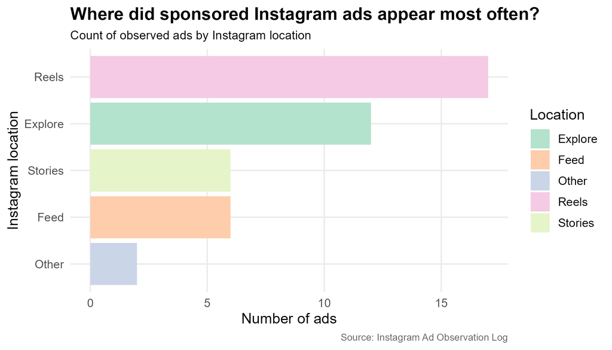

Horizontal bar chart showing where sponsored Instagram ads appeared. Reels had the highest count with 17 ads, followed by Explore with 12 ads. Feed and Stories had 6 ads each, while Other had the lowest count with 2 ads.

Sponsored ads were not spread evenly across Instagram locations. **Reels had the highest number of observed ads with 17**, followed by **Explore with 12**. Feed and Stories each had 6 ads, while Other had the fewest at just 2.

This pattern reflects how Instagram surfaces content. Reels and Explore are both designed for continuous, open-ended scrolling through new material — making them natural spaces for ad delivery. Feed and Stories tend to be more intentional, with users viewing content from people they already follow, which may explain the lower ad frequency in those locations.

## Entertainment ads held attention the longest

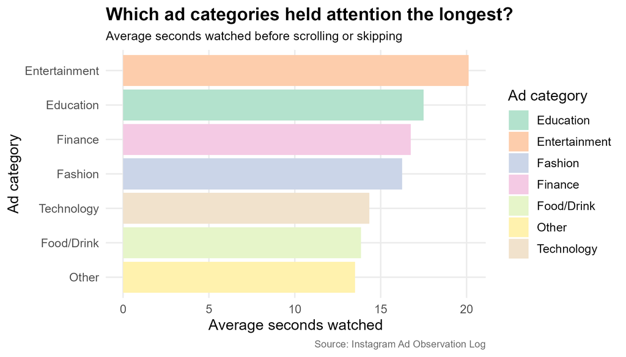

Horizontal bar chart showing average seconds watched by ad category. Entertainment ads had the longest average watch time at about 20 seconds, followed by Education, Finance, Fashion, Technology, Food or Drink, and Other.

Looking beyond frequency, this plot measures **which types of ads actually held attention**. Entertainment ads had the highest average watch time at around **20 seconds** — the longest of any category. Education and Finance ads followed closely, while Food or Drink and Other had the shortest average viewing times.

This distinction matters: an ad category does not need to appear most often to be effective. Entertainment ads may hold attention because their content — video clips, humour, or storytelling — is harder to distinguish from non-sponsored Reels at a glance, making it more likely that a viewer watches before realising it is an ad.

## Relevance seemed connected to longer watch time

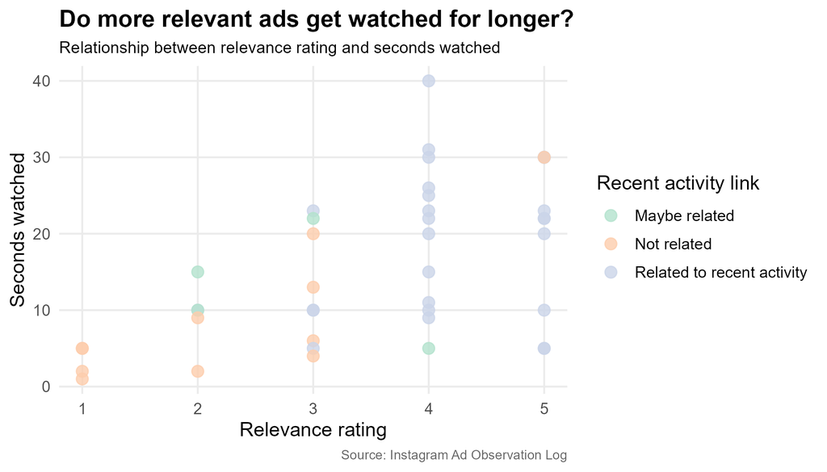

Scatter plot comparing relevance rating and seconds watched. Lower relevance ratings around 1 and 2 mostly had shorter viewing times, while ratings of 4 and 5 included many longer viewing times. Points are coloured by whether the ad seemed related to recent activity.

The colour grouping adds a second layer to the story. Ads that seemed connected to recent activity — recent searches, purchases, or viewed content — clustered toward the higher relevance ratings. This supports the idea that Instagram’s ad targeting creates a feedback loop: when an ad connects to something the user has already done, it feels more relevant and gets watched for longer.

## The observations happened in bursts

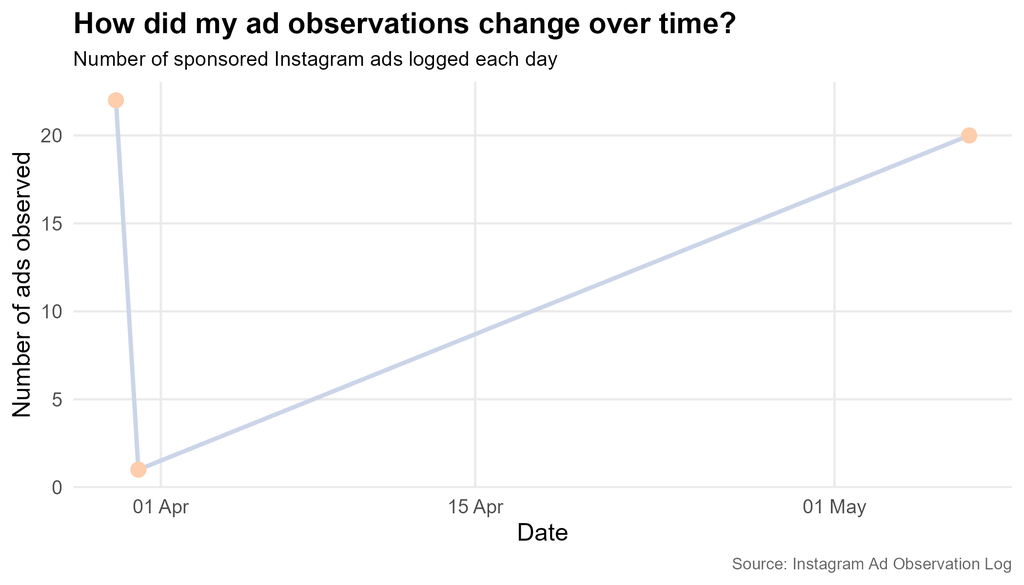

Line chart showing the number of sponsored Instagram ads logged each day. The data shows a high number of observations around 30 March, a very low count around 31 March, and another high count in early May.

This final plot shifts from asking *what* the ads were like to asking *when* the data was collected. Rather than a steady stream of observations, logging happened in clear bursts — a high count around **30 March**, an almost zero count on **31 March**, and another cluster in **early May**.

This is important context for interpreting the earlier plots. Days with heavy Instagram use may have produced different types of ads than quieter days, and the category or relevance patterns observed could reflect the algorithm’s response to a particular session rather than a stable long-term pattern.

## Overall, the ads looked moderately personalised

Across the four visualisations, a consistent picture emerges. Sponsored Instagram ads appeared most often in **Reels and Explore** — the parts of the app designed for discovering new content. **Entertainment ads** held attention the longest, likely because their format blends naturally with non-sponsored video content. And **higher relevance ratings generally aligned with longer watch times**, with ads connected to recent activity scoring both higher on relevance and attracting more viewing time.

Taken together, these patterns suggest **moderate personalisation**: the algorithm appears to use browsing and purchase behaviour to surface ads that feel relevant, and those ads are rewarded with more attention. However, because this dataset comes from one person’s observations over a limited period, the findings reflect personal patterns rather than universal conclusions about how Instagram’s advertising system works.